# Analyzing the Effects of Social and Economic Factors on Students’ Dropout and Academic Success

## About Dataset

- `Datasource[Kaggle]`: https://www.kaggle.com/datasets/thedevastator/higher-education-predictors-of-student-retention
- This dataset provides data on undergraduate students, including their demographics, socioeconomic status, and academic performance, with the aim of investigating the influence of these factors on student dropout rates and academic success. Additionally, the data will be used to build a machine learning model to predict whether a student is likely to drop out or not.
- Marital status
- Application mode
- Application order
- Course
- Daytime/evening attendance
- Previous qualification
- Nationality
- Mother’s qualification
- Father’s qualification
- Mother’s occupation
- Father’s occupation
- Displacement status
- Educational special needs
- Debtor status
- Tuition fees up to date status
- Gender
- Scholarship holder status
- Age at enrollment
- International student status
- Number of curricular units credited, enrolled, evaluated, and approved in the first semester.

### —————————————————————————-

# 1. Data Pre-Processing

#### 1.1 Read and check the data

```r
ac <- read.csv("academic success.csv", header = TRUE)
```

#### 1.2 Replace Enrolled with Graduate

- I decided to combine the Enrolled and Graduate categories and renamed it as “Graduate” to simplify the analysis.
- This information is crucial as it provides insights into the overall distribution of student outcomes and serves as a baseline for subsequent analysis.
- Understanding the distribution of the outcome variable is an essential first step in any analysis, as it helps to inform subsequent analysis and interventions aimed at improving student retention rates in undergraduate programs.

```r
ac$Target <- ifelse(ac$Target == "Enrolled", "Graduate", ac$Target)
table(ac$Target)
```

```
##
##  Dropout Graduate
##     1421     3003
```

#### 1.3 Check for missing values

- There is no NaN

```r
sum(is.na(ac))
```

```
## [1] 0
```

#### 1.4 Summary statistics for all variables

```r
summary(ac)
```

```
##  MaritalStatus   ApplicationMode  ApplicationOrder     Course
##  Min.   :1.000   Min.   : 1.000   Min.   :0.000    Min.   : 1.000
##  1st Qu.:1.000   1st Qu.: 1.000   1st Qu.:1.000    1st Qu.: 6.000
##  Median :1.000   Median : 8.000   Median :1.000    Median :10.000
##  Mean   :1.179   Mean   : 6.887   Mean   :1.728    Mean   : 9.899
##  3rd Qu.:1.000   3rd Qu.:12.000   3rd Qu.:2.000    3rd Qu.:13.000
##  Max.   :6.000   Max.   :18.000   Max.   :9.000    Max.   :17.000
##     DayNight         PreQual        Nationality       MotherQual
##  Min.   :0.0000   Min.   : 1.000   Min.   : 1.000   Min.   : 1.00
##  1st Qu.:1.0000   1st Qu.: 1.000   1st Qu.: 1.000   1st Qu.: 2.00
##  Median :1.0000   Median : 1.000   Median : 1.000   Median :13.00
##  Mean   :0.8908   Mean   : 2.531   Mean   : 1.255   Mean   :12.32
##  3rd Qu.:1.0000   3rd Qu.: 1.000   3rd Qu.: 1.000   3rd Qu.:22.00
##  Max.   :1.0000   Max.   :17.000   Max.   :21.000   Max.   :29.00
##    FatherQual      MotherOccu       FatherOccu       Displaced
##  Min.   : 1.00   Min.   : 1.000   Min.   : 1.000   Min.   :0.0000
##  1st Qu.: 3.00   1st Qu.: 5.000   1st Qu.: 5.000   1st Qu.:0.0000
##  Median :14.00   Median : 6.000   Median : 8.000   Median :1.0000
##  Mean   :16.46   Mean   : 7.318   Mean   : 7.819   Mean   :0.5484
##  3rd Qu.:27.00   3rd Qu.:10.000   3rd Qu.:10.000   3rd Qu.:1.0000
##  Max.   :34.00   Max.   :32.000   Max.   :46.000   Max.   :1.0000
##    SpecialEdu          Debtor        TuitionFees         Gender
##  Min.   :0.00000   Min.   :0.0000   Min.   :0.0000   Min.   :0.0000
##  1st Qu.:0.00000   1st Qu.:0.0000   1st Qu.:1.0000   1st Qu.:0.0000
##  Median :0.00000   Median :0.0000   Median :1.0000   Median :0.0000
##  Mean   :0.01153   Mean   :0.1137   Mean   :0.8807   Mean   :0.3517
##  3rd Qu.:0.00000   3rd Qu.:0.0000   3rd Qu.:1.0000   3rd Qu.:1.0000
##  Max.   :1.00000   Max.   :1.0000   Max.   :1.0000   Max.   :1.0000
##   Scholarship       AgeEnroll     International      FirSemCredit
##  Min.   :0.0000   Min.   :17.00   Min.   :0.00000   Min.   : 0.00
##  1st Qu.:0.0000   1st Qu.:19.00   1st Qu.:0.00000   1st Qu.: 0.00
##  Median :0.0000   Median :20.00   Median :0.00000   Median : 0.00
##  Mean   :0.2484   Mean   :23.27   Mean   :0.02486   Mean   : 0.71
##  3rd Qu.:0.0000   3rd Qu.:25.00   3rd Qu.:0.00000   3rd Qu.: 0.00
##  Max.   :1.0000   Max.   :70.00   Max.   :1.00000   Max.   :20.00
##   FirSemEnroll      FirSemEval     FirSemApprove     FirSemGrade
##  Min.   : 0.000   Min.   : 0.000   Min.   : 0.000   Min.   : 0.00
##  1st Qu.: 5.000   1st Qu.: 6.000   1st Qu.: 3.000   1st Qu.:11.00
##  Median : 6.000   Median : 8.000   Median : 5.000   Median :12.29
##  Mean   : 6.271   Mean   : 8.299   Mean   : 4.707   Mean   :10.64
```

[output cut: 8 more lines]

```
##  Max.   :12.0000   Max.   :19.0000   Max.   :23.000   Max.   :33.000
##  SecSemApprove     SecSemGrade     SecSemNoEval       UnempRate
##  Min.   : 0.000   Min.   : 0.00   Min.   : 0.0000   Min.   : 7.60
##  1st Qu.: 2.000   1st Qu.:10.75   1st Qu.: 0.0000   1st Qu.: 9.40
##  Median : 5.000   Median :12.20   Median : 0.0000   Median :11.10
##  Mean   : 4.436   Mean   :10.23   Mean   : 0.1503   Mean   :11.57
##  3rd Qu.: 6.000   3rd Qu.:13.33   3rd Qu.: 0.0000   3rd Qu.:13.90
##  Max.   :20.000   Max.   :18.57   Max.   :12.0000   Max.   :16.20
##  InflationRate         GDP               Target
##  Min.   :-0.800   Min.   :-4.060000   Length:4424
##  1st Qu.: 0.300   1st Qu.:-1.700000   Class :character
##  Median : 1.400   Median : 0.320000   Mode  :character
##  Mean   : 1.228   Mean   : 0.001969
##  3rd Qu.: 2.600   3rd Qu.: 1.790000
##  Max.   : 3.700   Max.   : 3.510000
```

#### 1.5 Check Structure for all variables

```r
str(ac)
```

```
## 'data.frame':    4424 obs. of  35 variables:
##  $ MaritalStatus   : int  1 1 1 1 2 2 1 1 1 1 ...
##  $ ApplicationMode : int  8 6 1 8 12 12 1 9 1 1 ...
##  $ ApplicationOrder: int  5 1 5 2 1 1 1 4 3 1 ...
##  $ Course          : int  2 11 5 15 3 17 12 11 10 10 ...
##  $ DayNight        : int  1 1 1 1 0 0 1 1 1 1 ...
##  $ PreQual         : int  1 1 1 1 1 12 1 1 1 1 ...
##  $ Nationality     : int  1 1 1 1 1 1 1 1 15 1 ...
##  $ MotherQual      : int  13 1 22 23 22 22 13 22 1 1 ...
##  $ FatherQual      : int  10 3 27 27 28 27 28 27 1 14 ...
##  $ MotherOccu      : int  6 4 10 6 10 10 8 10 10 5 ...
##  $ FatherOccu      : int  10 4 10 4 10 8 11 10 10 8 ...
##  $ Displaced       : int  1 1 1 1 0 0 1 1 0 1 ...
##  $ SpecialEdu      : int  0 0 0 0 0 0 0 0 0 0 ...
##  $ Debtor          : int  0 0 0 0 0 1 0 0 0 1 ...
```

[output cut: 21 more lines]

### —————————————————————————-

# 2. Exploratory Data Analysis (EDA)

#### 2.1 Load Library

```r
library(ggplot2)
library(corrplot)
library(gridExtra)
library(psych)
library(reshape2)
```

#### 2.2 Distribution of the target variable

- The resulting table of the outcome variable showed that there are 1421 dropouts and 3003 graduates, with a dropout rate of approximately 32%.

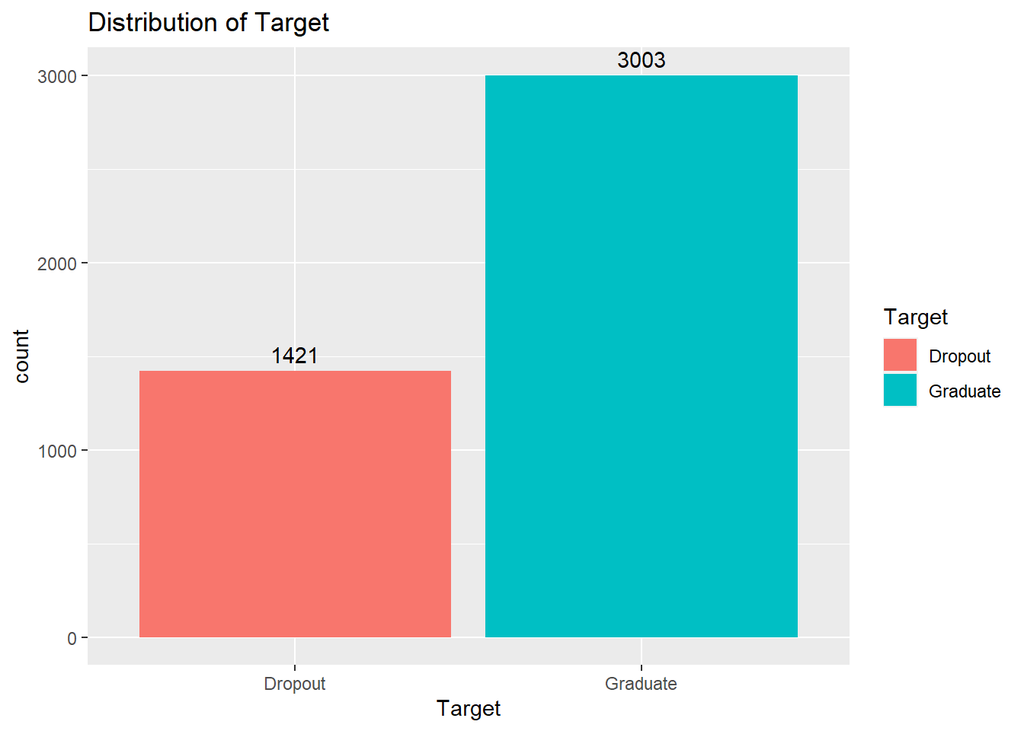

```r
ggplot(ac, aes(x = Target)) +
  geom_bar(stat = "count", aes(fill = Target)) +
  geom_text(stat='count', aes(label=after_stat(count)), vjust=-0.5)+
  labs(title = "Distribution of Target")
```

#### 2.3 Distribution of Socioeconomic Factor Variables

- The socioeconomic factor variables (such as `GDP`, `Inflation Rate`, and `Unemployment Rate`) are equally distributed between students who dropped out and those who graduated.
- However, there are outliers in the distribution of mother/father occupation and age at enrollment.

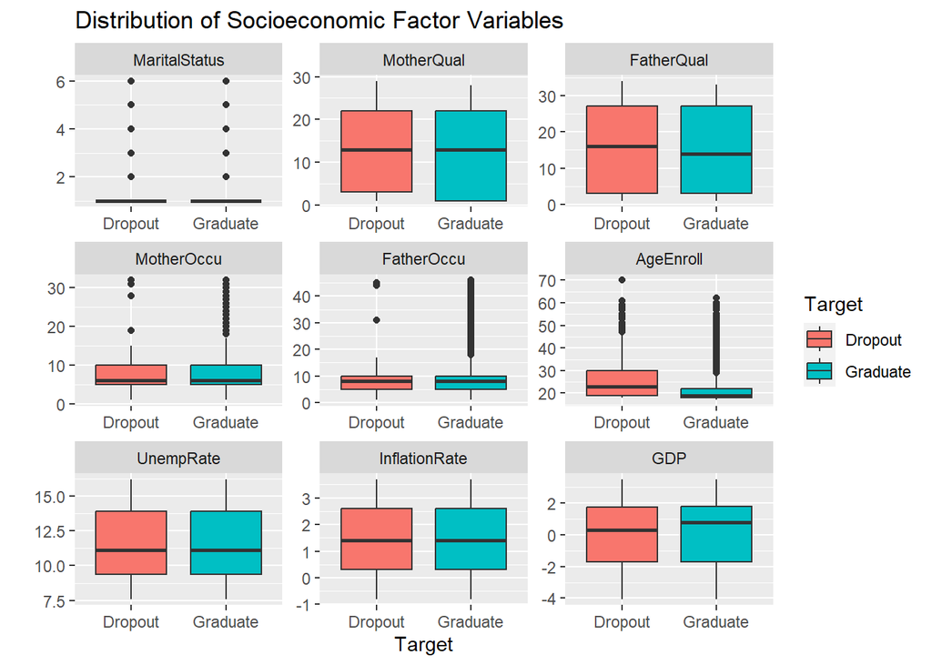

```r
macro_boxplot <- ac[, c("Target",
                        "MaritalStatus",
                        "MotherQual",
                        "FatherQual",
                        "MotherOccu",
                        "FatherOccu",
                        "AgeEnroll",
                        "UnempRate",
                        "InflationRate",
                        "GDP")]

macro_melt <- melt(macro_boxplot, id.vars = "Target")

ggplot(macro_melt, aes(x = Target, y = value, fill = Target)) +
  geom_boxplot() +
  facet_wrap(~ variable, scales = "free") +
  labs(title = "Distribution of Socioeconomic Factor Variables", y = "")
```